# Criteo Interview

Vladimir Mikheev

05 07 2021

# 1. Revenue change over time

Let’s observe annual dynamics of revenue.

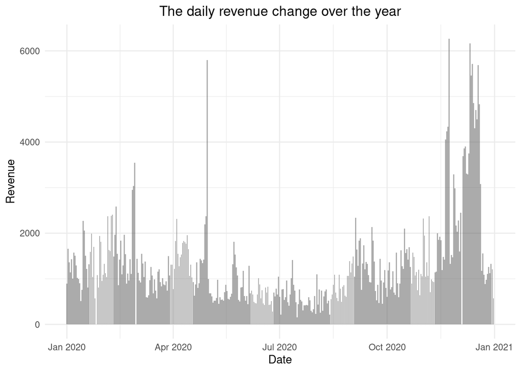

[figure not shown]

```r
ggplot(df_rev, aes(x = Date, y = Revenue )) +
  geom_col(alpha = 0.5) +
  ggtitle('The daily revenue change over the year') +
  theme_minimal() +
  theme(plot.title = element_text(hjust = 0.5))
```

The main characteristics of revenue over year.

| mean | median | min | max |
| --- | --- | --- | --- |
| 1302.873 | 1061 | 154 | 6265 |

**Recommendations:**

## 2.2 Did problems with android app affect graph over the year?

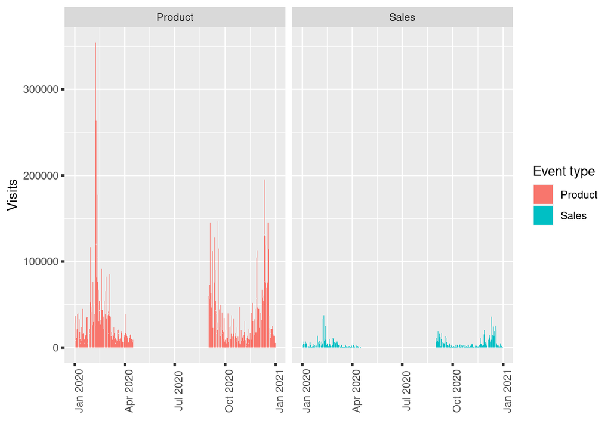

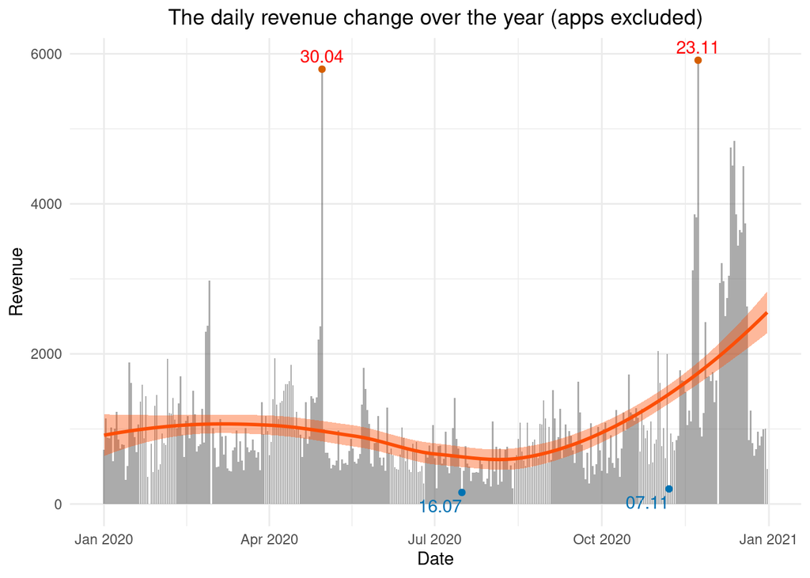

| mean | median | min | max |
| --- | --- | --- | --- |
| 1068.262 | 850 | 154 | 5914 |

We excluded Android app, however we stil observe summer drop in revenue.

# 2. Device usage change over year

Let’s observe annual dynamics of revenue for every type of devices.

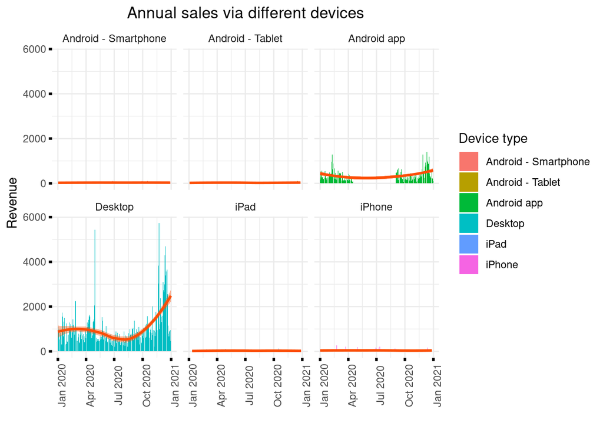

These plots do not provide us a new meaningful information except the necessity to check what happens on summer with Android apps.

Let’s group different devices on four types: smart phones, tablets, Desktop and, special case, Android app.

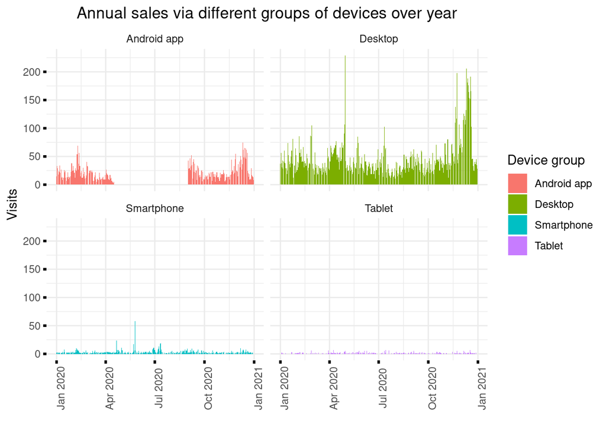

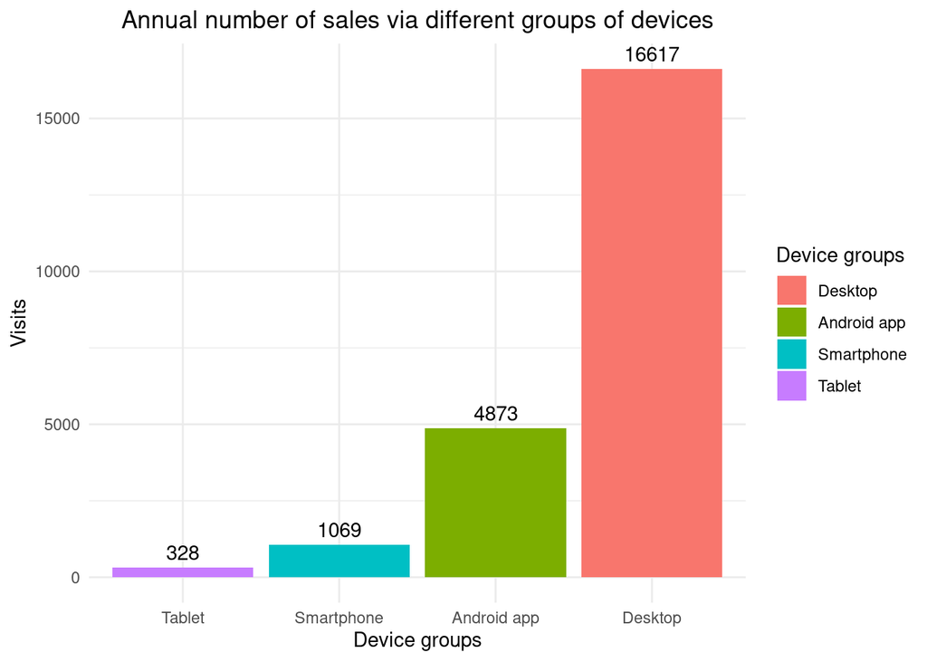

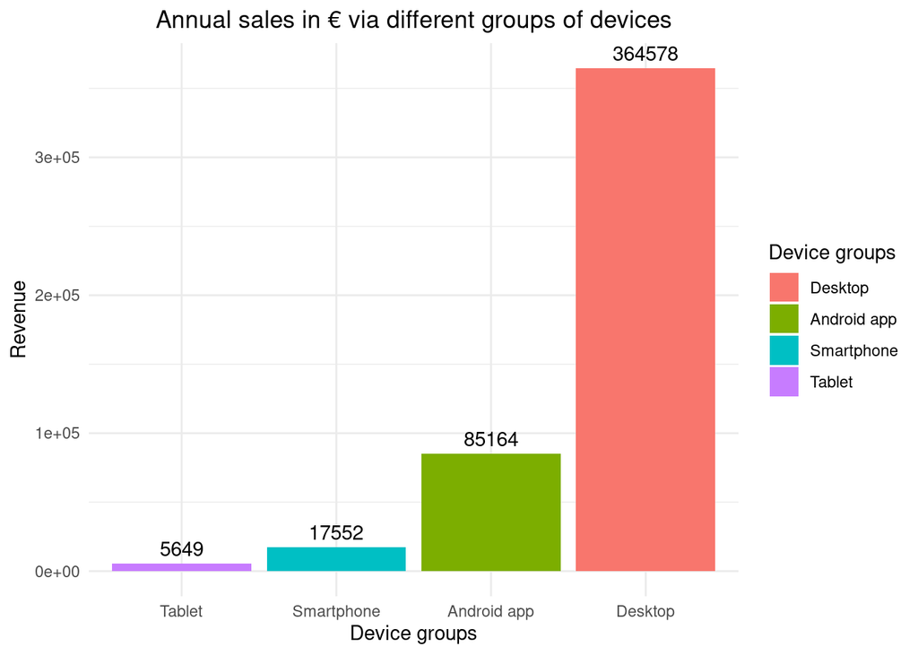

Let’s discover is this difference is significant?

|  | Revenue |  |  |
| --- | --- | --- | --- |
| Predictors | Estimates | CI | p |
| (Intercept) | 21.94 | 21.70 – 22.18 | **<0.001** |
| Device group [Tablet] | -4.72 | -6.45 – -2.99 | **<0.001** |
| Device group [Smartphone] | -5.52 | -6.50 – -4.54 | **<0.001** |
| Device group [Android app] | -4.46 | -4.97 – -3.96 | **<0.001** |
| Observations | 22887 |  |  |
| R<sup>2</sup> / R<sup>2</sup> adjusted | 0.017 / 0.017 |  |  |

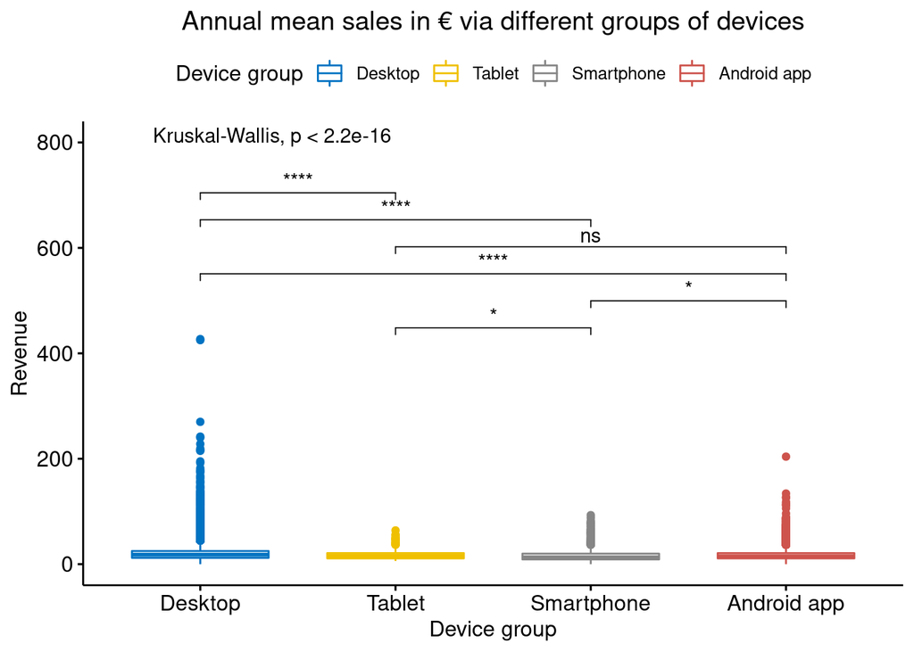

**Recommendations:**

1. Make Desktop advertising the main target of sdvertising campaigns.
2. In smartphones more spensings occur via applications than via mobile web.
3. A few number of users buy products through tablets and advertising via tablets is irrelevant.

# 3. Apps VS Mobile Web

## 3.1. App vs web

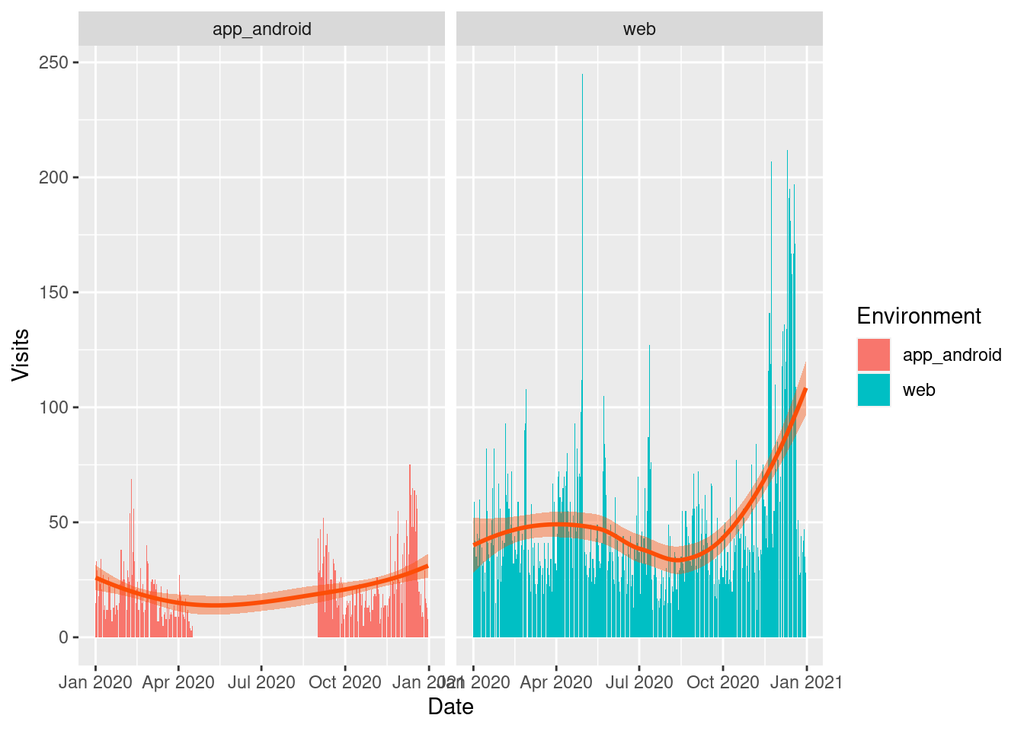

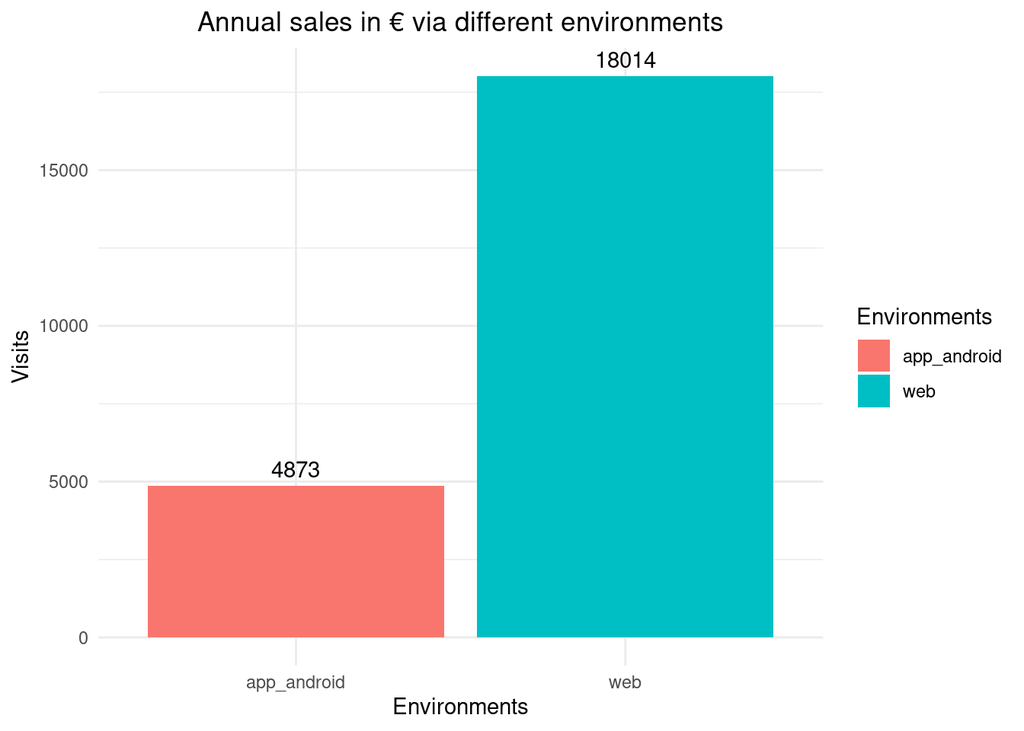

We may observe that web purchasing is 4 times higher than application sales and especially in the end of the year.

## 3.2 Application vs Mobile web

However, the main question is concerned on comparison of applications with mobile web, not web as it is.

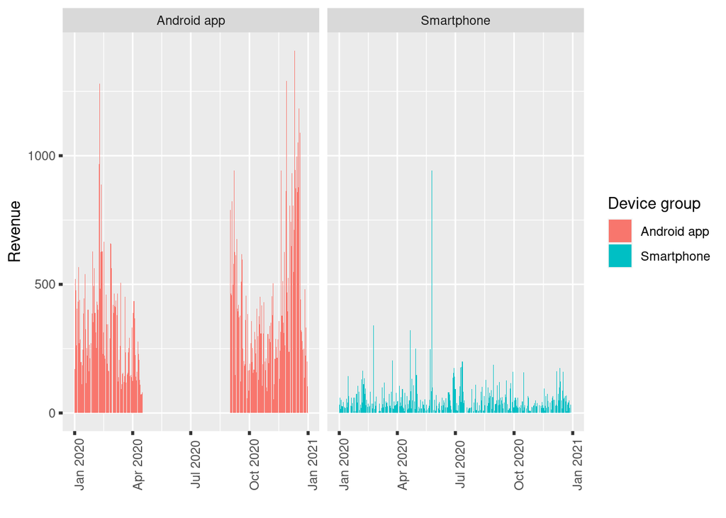

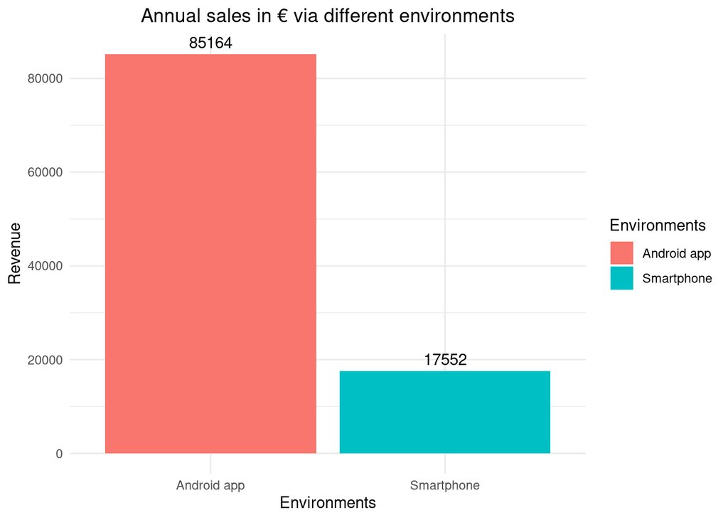

|  | Revenue |  |  |
| --- | --- | --- | --- |
| Predictors | Estimates | CI | p |
| (Intercept) | 526.63 | 518.37 – 534.88 | **<0.001** |
| Device group [Smartphone] | -391.13 | -410.59 – -371.67 | **<0.001** |
| Observations | 5942 |  |  |
| R<sup>2</sup> / R<sup>2</sup> adjusted | 0.207 / 0.207 |  |  |

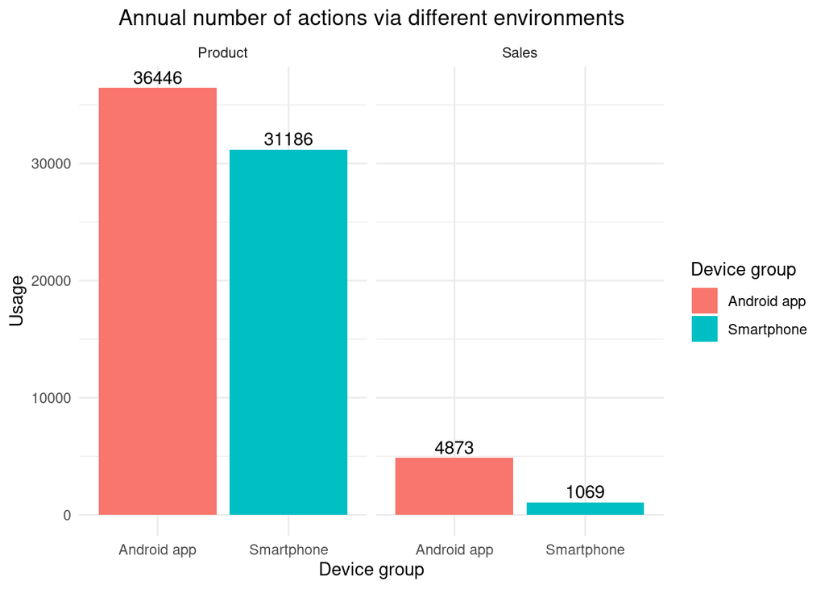

The company obtains by 4.9 times higher revenue through android app than through mobile web.

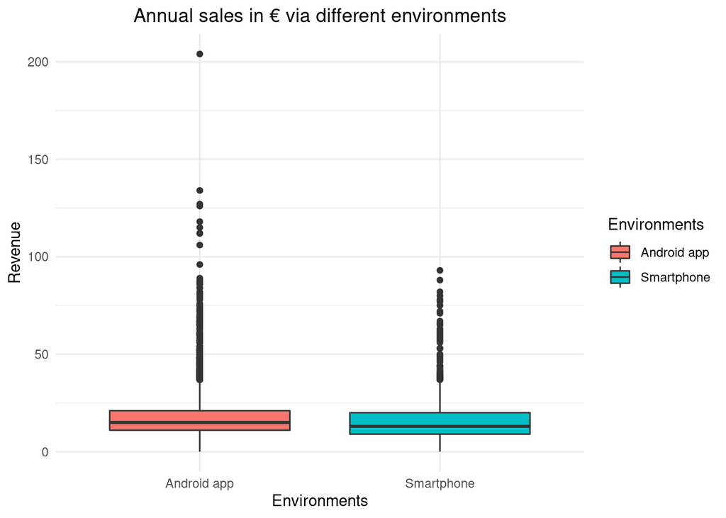

|  | Revenue |  |  |
| --- | --- | --- | --- |
| Predictors | Estimates | CI | p |
| (Intercept) | 17.48 | 17.13 – 17.83 | **<0.001** |
| Device group [Smartphone] | -1.06 | -1.88 – -0.23 | **0.012** |
| Observations | 5942 |  |  |
| R<sup>2</sup> / R<sup>2</sup> adjusted | 0.001 / 0.001 |  |  |

A mean revenue through Android app is by 1.05 higher than revenue through mobile web.

**Recommendations:**

1. There were a technical problems with Android applications in summer months there is no information about sale and product events. Company should solve this technical problem.
2. Company will obtain more revenue if will focus on promotion of its application as soon as (although there were no data in summer on application usage) it generates: - almost 5 times more total revenue than mobile web; - 391 more mean daily revenue than mobile web; - 5% more mean revenue than mobile web.
3. There was a short peak of mobile web usage in summer when there was no data about application usage.
4. However there is no listing and basketing options in application. There is a need in additional investigation about their usefulness for revenue increasing.